# Stat333 project 1

```r
BodyFat = read.csv("BodyFat.csv")
attach(BodyFat)
dim(BodyFat)
```

```
## [1] 252  17
```

```r
colnames(BodyFat)
```

```
##  [1] "IDNO"      "BODYFAT"   "DENSITY"   "AGE"       "WEIGHT"    "HEIGHT"
##  [7] "ADIPOSITY" "NECK"      "CHEST"     "ABDOMEN"   "HIP"       "THIGH"
## [13] "KNEE"      "ANKLE"     "BICEPS"    "FOREARM"   "WRIST"
```

## Step 1: Analyzing Raw Data

1. We first take a look at the head of the data set(first 6 rows) and the tail of the data set(last 6 rows) to get a general format of the data frame. Each row represents one single person with his ID number and 16 other body measurements. Our response variable is the percent body fat. We exclude the ID number and density in our model to predict body fat since ID number is irrelevant and density is a direct measurement for body fat.
2. An interesting pattern to notice is that weight and height are measured in increment of 0.25 pound and inch, while abdomen, chest, and other measurements are more precisely measured.
3. We then check the data set’s summary. We can see some relatively abnormal data. For example, the minimum of body fat is 0 percent, which is impossible in real life. Also, the max percent body fat is 45%, which means that nearly half of the person’ body is fat. Looking at the height, there is a person whose height is only 29.5 inches. These data are highly unlikely to happen(while still possible in some cases). We should be aware of these points and perhaps exclude them when cleaning the data if necessary.

```r
head(BodyFat)
```

```
##   IDNO BODYFAT DENSITY AGE WEIGHT HEIGHT ADIPOSITY NECK CHEST ABDOMEN   HIP
## 1    1    12.6  1.0708  23 154.25  67.75      23.7 36.2  93.1    85.2  94.5
## 2    2     6.9  1.0853  22 173.25  72.25      23.4 38.5  93.6    83.0  98.7
## 3    3    24.6  1.0414  22 154.00  66.25      24.7 34.0  95.8    87.9  99.2
## 4    4    10.9  1.0751  26 184.75  72.25      24.9 37.4 101.8    86.4 101.2
## 5    5    27.8  1.0340  24 184.25  71.25      25.6 34.4  97.3   100.0 101.9
## 6    6    20.6  1.0502  24 210.25  74.75      26.5 39.0 104.5    94.4 107.8
##   THIGH KNEE ANKLE BICEPS FOREARM WRIST
## 1  59.0 37.3  21.9   32.0    27.4  17.1
## 2  58.7 37.3  23.4   30.5    28.9  18.2
## 3  59.6 38.9  24.0   28.8    25.2  16.6
## 4  60.1 37.3  22.8   32.4    29.4  18.2
## 5  63.2 42.2  24.0   32.2    27.7  17.7
## 6  66.0 42.0  25.6   35.7    30.6  18.8
```

```r
tail(BodyFat)
```

```
##     IDNO BODYFAT DENSITY AGE WEIGHT HEIGHT ADIPOSITY NECK CHEST ABDOMEN   HIP
## 247  247    29.1  1.0308  69 215.50  70.50      30.5 40.8 113.7   107.6 110.0
## 248  248    11.5  1.0736  70 134.25  67.00      21.1 34.9  89.2    83.6  88.8
## 249  249    32.3  1.0236  72 201.00  69.75      29.1 40.9 108.5   105.0 104.5
## 250  250    28.3  1.0328  72 186.75  66.00      30.2 38.9 111.1   111.5 101.7
## 251  251    25.3  1.0399  72 190.75  70.50      27.0 38.9 108.3   101.3  97.8
## 252  252    30.7  1.0271  74 207.50  70.00      29.8 40.8 112.4   108.5 107.1
##     THIGH KNEE ANKLE BICEPS FOREARM WRIST
## 247  63.3 44.0  22.6   37.5    32.6  18.8
## 248  49.6 34.8  21.5   25.6    25.7  18.5
## 249  59.6 40.8  23.2   35.2    28.6  20.1
## 250  60.3 37.3  21.5   31.3    27.2  18.0
## 251  56.0 41.6  22.7   30.5    29.4  19.8
## 252  59.3 42.2  24.6   33.7    30.0  20.9
```

```r
summary(BodyFat)
```

```
##       IDNO           BODYFAT         DENSITY           AGE
##  Min.   :  1.00   Min.   : 0.00   Min.   :0.995   Min.   :22.00
##  1st Qu.: 63.75   1st Qu.:12.80   1st Qu.:1.041   1st Qu.:35.75
##  Median :126.50   Median :19.00   Median :1.055   Median :43.00
##  Mean   :126.50   Mean   :18.94   Mean   :1.056   Mean   :44.88
##  3rd Qu.:189.25   3rd Qu.:24.60   3rd Qu.:1.070   3rd Qu.:54.00
##  Max.   :252.00   Max.   :45.10   Max.   :1.109   Max.   :81.00
##      WEIGHT          HEIGHT        ADIPOSITY          NECK
##  Min.   :118.5   Min.   :29.50   Min.   :18.10   Min.   :31.10
##  1st Qu.:159.0   1st Qu.:68.25   1st Qu.:23.10   1st Qu.:36.40
##  Median :176.5   Median :70.00   Median :25.05   Median :38.00
##  Mean   :178.9   Mean   :70.15   Mean   :25.44   Mean   :37.99
##  3rd Qu.:197.0   3rd Qu.:72.25   3rd Qu.:27.32   3rd Qu.:39.42
##  Max.   :363.1   Max.   :77.75   Max.   :48.90   Max.   :51.20
##      CHEST           ABDOMEN            HIP            THIGH
##  Min.   : 79.30   Min.   : 69.40   Min.   : 85.0   Min.   :47.20
##  1st Qu.: 94.35   1st Qu.: 84.58   1st Qu.: 95.5   1st Qu.:56.00
##  Median : 99.65   Median : 90.95   Median : 99.3   Median :59.00
##  Mean   :100.82   Mean   : 92.56   Mean   : 99.9   Mean   :59.41
##  3rd Qu.:105.38   3rd Qu.: 99.33   3rd Qu.:103.5   3rd Qu.:62.35
##  Max.   :136.20   Max.   :148.10   Max.   :147.7   Max.   :87.30
##       KNEE           ANKLE          BICEPS         FOREARM          WRIST
##  Min.   :33.00   Min.   :19.1   Min.   :24.80   Min.   :21.00   Min.   :15.80
##  1st Qu.:36.98   1st Qu.:22.0   1st Qu.:30.20   1st Qu.:27.30   1st Qu.:17.60
##  Median :38.50   Median :22.8   Median :32.05   Median :28.70   Median :18.30
##  Mean   :38.59   Mean   :23.1   Mean   :32.27   Mean   :28.66   Mean   :18.23
##  3rd Qu.:39.92   3rd Qu.:24.0   3rd Qu.:34.33   3rd Qu.:30.00   3rd Qu.:18.80
##  Max.   :49.10   Max.   :33.9   Max.   :45.00   Max.   :34.90   Max.   :21.40
```

Then, in order to get a better sense of which body measurement should be closely related to percent body fat, we can do a background research. Here are two images I found when searching for body fat. Our best guess at this point is that the percent body fat could be closely correlated with weight, thigh, abdomen and chest circumferences since as the percent body fat increases, these measurements increase evidently.

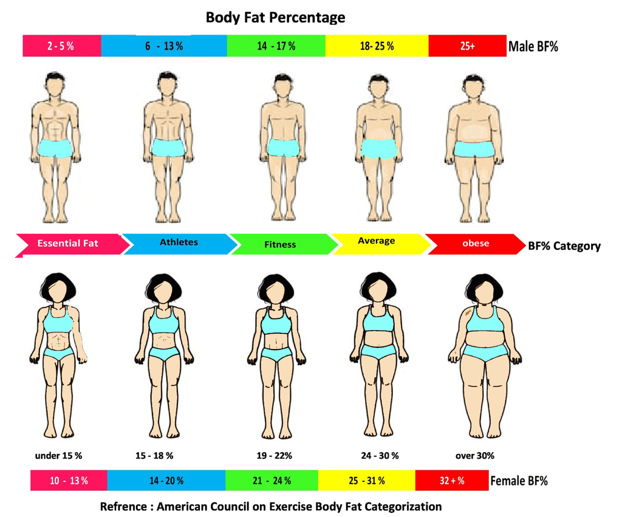

alt text

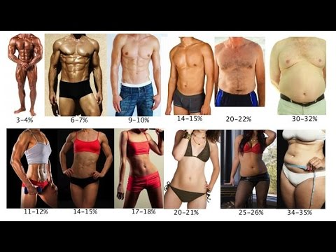

alt text

5. Further checking, we extract the correlation table between body fat and all other factors in the data set. We get more confident that the percent body fat is closely related to chest and abdomen circumferences. Also, the correlation between body fat and adiposity is also fairly high. We could focus more on this predictor later in our analysis as well. However, the correlation between weight and body fat, thigh circumference and body fat is not so high comparing to those factors.

```r
correlation = cor(BodyFat)
correlation[2, 4:17]
```

```
##         AGE      WEIGHT      HEIGHT   ADIPOSITY        NECK       CHEST
##  0.28917352  0.61315611 -0.08910641  0.72799418  0.49148893  0.70288516
##     ABDOMEN         HIP       THIGH        KNEE       ANKLE      BICEPS
##  0.81370622  0.62569993  0.56128438  0.50778587  0.26678256  0.49303089
##     FOREARM       WRIST
##  0.36327744  0.34757276
```

6. We then order the factors in descending order by their correlation with body fat and pick the first four largest of them to focus on. Next, we draw a sample by 5 among the 252 data and only look at these three measurements. Then, we order the sample by percent body fat in ascending order. We can see that generally all these four measurements have a positive relationship with body fat. That is, as these measurements increase, the percent body fat also increases. Thus, we may limit our prediction by focusing on these four measurements: Chest, Abdomen, Adiposity, and hip.

```r
list = sort(correlation[2, 4:17], decreasing = TRUE)
list[1:4] # highest three correlation with body fat
```

```
##   ABDOMEN ADIPOSITY     CHEST       HIP
## 0.8137062 0.7279942 0.7028852 0.6256999
```

```r
sample = BodyFat[seq(1, 252, 5), c("BODYFAT","CHEST","ABDOMEN","ADIPOSITY","HIP")]
sample[order(sample$BODYFAT), ]
```

```
##     BODYFAT CHEST ABDOMEN ADIPOSITY   HIP
## 171     4.1  92.2    81.9      23.4  92.8
## 26      4.6  89.6    79.7      21.9  96.5
## 11      7.5 101.5    83.6      23.6  98.2
## 211     7.8  91.2    79.4      21.4  89.0
## 186     9.2  89.5    83.7      23.1  98.1
## 151     9.9  92.9    77.6      22.5  93.5
## 161     9.9  94.0    81.2      20.4  91.5
## 176    10.4  96.8    79.4      21.3  89.2
## 51     10.7  90.2    86.7      21.3  98.3
## 231    11.1  99.6    86.4      24.1  90.1
## 191    11.8  91.4    80.6      22.5  92.3
## 31     12.3 100.5    88.7      23.6  99.8
## 201    12.5 102.7    89.2      25.4  99.2
## 1      12.6  93.1    85.2      23.7  94.5
```

[output cut: 37 more lines]

## Step 2: Visualizing Data

We want to plot Histograms of each variables in this step. It seems like majority of individuals chest circumference is around 100 cm, of Abdomen circumference is 90 cm, of Adioposity is 23 bmi, and of hip circumference is 100 cm. We can also observe some obvious outliers in the histograms. For example, in the chest histogram, there are outliers around 130 cm and 140 cm.

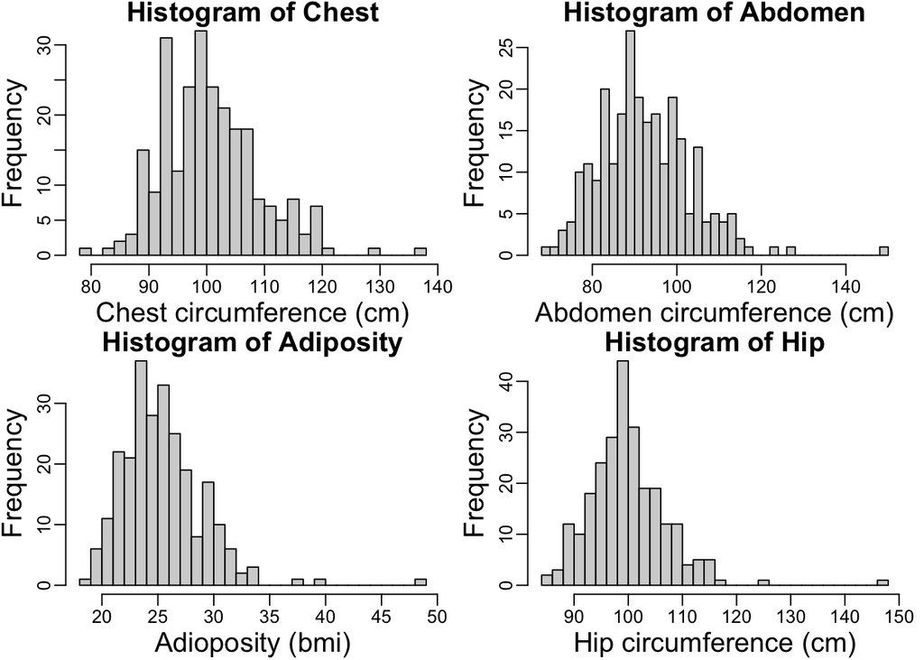

```r
par(mfrow=c(2,2))
par(mgp=c(1.8,.5,0), mar=c(3,3,1,1))
hist(BodyFat$CHEST,breaks=30,cex.lab=1.5,cex.main=1.5, main="Histogram of Chest",xlab="Chest circumference (cm)")
hist(BodyFat$ABDOMEN,breaks=30,cex.lab=1.5,cex.main=1.5, main="Histogram of Abdomen",xlab="Abdomen circumference (cm)")
hist(BodyFat$ADIPOSITY,breaks=30,cex.lab=1.5,cex.main=1.5, main="Histogram of Adiposity",xlab="Adioposity (bmi)")
hist(BodyFat$HIP,breaks=30,cex.lab=1.5,cex.main=1.5,main="Histogram of Hip",xlab="Hip circumference (cm)")
```

It seems like majority of individuals bodyfat is around 20%, of height is 70 inches, of age is 40 yrs, and of weight is 175 lbs.

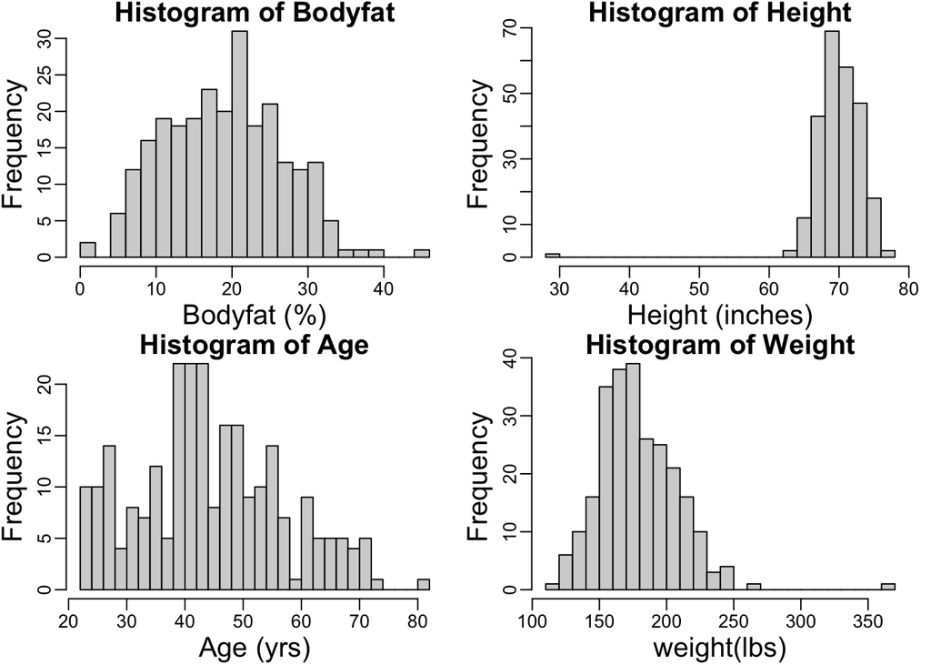

```r
par(mfrow=c(2,2))
par(mgp=c(1.8,.5,0), mar=c(3,3,1,1))
hist(BodyFat$BODYFAT,breaks=30,cex.lab=1.5,cex.main=1.5, main="Histogram of Bodyfat",xlab="Bodyfat (%)")
hist(BodyFat$HEIGHT,breaks=30,cex.lab=1.5,cex.main=1.5, main="Histogram of Height",xlab="Height (inches)")
hist(BodyFat$AGE,breaks=30,cex.lab=1.5,cex.main=1.5, main="Histogram of Age",xlab="Age (yrs)")
hist(BodyFat$WEIGHT,breaks=30,cex.lab=1.5,cex.main=1.5,main="Histogram of Weight",xlab="weight(lbs)")
```

The four histograms all seem to have the pattern of normal distribution. Majority of individuals have neck circumference around 37cm, thigh circumference around 58cm. There exists potential outliers when neck circumference equals to 51.2cm, thigh circumference equals to 87.3 cm, knee circumference equals to 49.1cm, ankle circumference equals to 33.9cm.

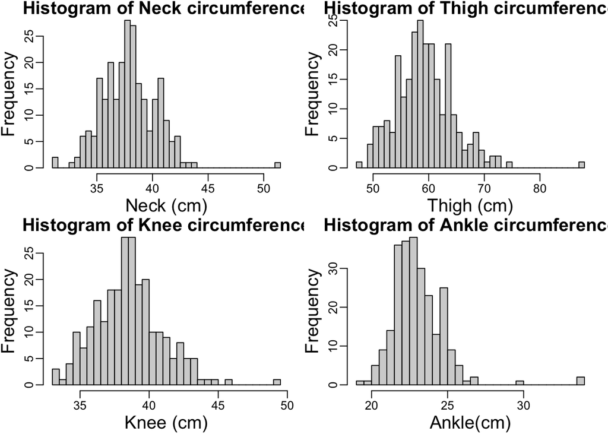

```r
par(mfrow=c(2,2))
par(mgp=c(1.8,.5,0), mar=c(3,3,1,1))
hist(BodyFat$NECK,breaks=30,cex.lab=1.5,cex.main=1.5, main="Histogram of Neck circumference",xlab="Neck (cm)")
hist(BodyFat$THIGH,breaks=30,cex.lab=1.5,cex.main=1.5, main="Histogram of Thigh circumference",xlab="Thigh (cm)")
hist(BodyFat$KNEE,breaks=30,cex.lab=1.5,cex.main=1.5, main="Histogram of Knee circumference",xlab="Knee (cm)")
hist(BodyFat$ANKLE,breaks=30,cex.lab=1.5,cex.main=1.5,main="Histogram of Ankle circumference",xlab="Ankle(cm)")
```

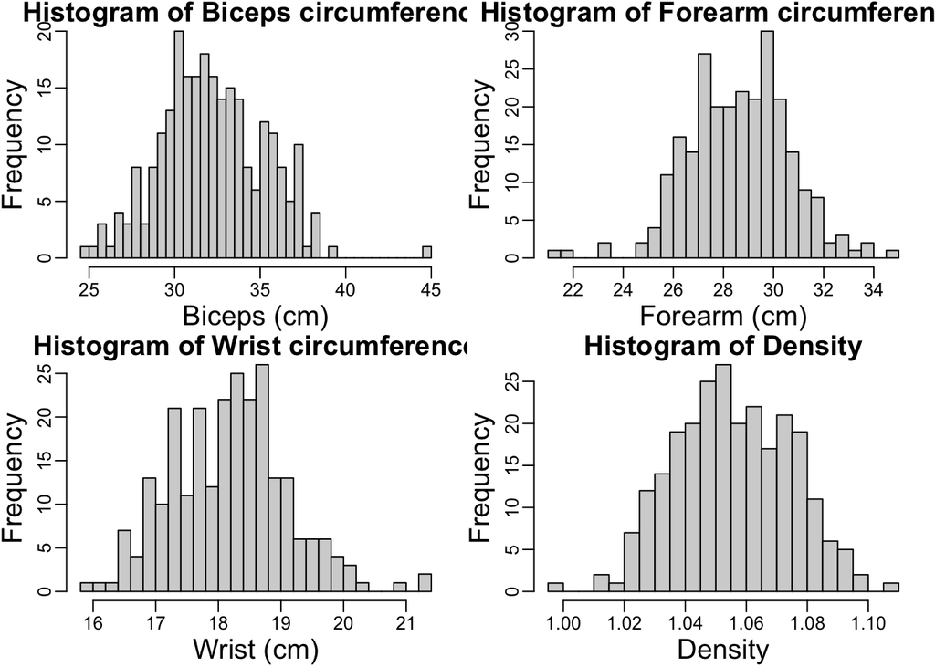

```r
par(mfrow=c(2,2))
par(mgp=c(1.8,.5,0), mar=c(3,3,1,1))
hist(BodyFat$BICEPS,breaks=30,cex.lab=1.5,cex.main=1.5, main="Histogram of Biceps circumference",xlab="Biceps (cm)")
hist(BodyFat$FOREARM,breaks=30,cex.lab=1.5,cex.main=1.5, main="Histogram of Forearm circumference",xlab="Forearm (cm)")
hist(BodyFat$WRIST,breaks=30,cex.lab=1.5,cex.main=1.5, main="Histogram of Wrist circumference",xlab="Wrist (cm)")
hist(BodyFat$DENSITY,breaks=30,cex.lab=1.5,cex.main=1.5,main="Histogram of Density",xlab="Density")
```

Based on the histograms, we want to look at subsets of the data.In this step, we mainly want to detect obvious outliers that are showing in histograms of each variables.Followings are the obvious outlier that can be observe in this dataset.

```r
BodyFat[BodyFat$CHEST > 120,]
```

```
##     IDNO BODYFAT DENSITY AGE WEIGHT HEIGHT ADIPOSITY NECK CHEST ABDOMEN   HIP
## 39    39    33.8  1.0202  46 363.15  72.25      48.9 51.2 136.2   148.1 147.7
## 41    41    33.1  1.0217  45 262.75  68.75      39.1 43.2 128.3   126.2 125.6
## 205  205    33.4  1.0209  44 223.00  69.75      32.3 40.9 121.6   113.9 107.1
##     THIGH KNEE ANKLE BICEPS FOREARM WRIST
## 39   87.3 49.1  29.6   45.0    29.0  21.4
## 41   72.5 39.6  26.6   36.4    32.7  21.4
## 205  63.5 40.3  21.8   34.8    30.7  17.4
```

```r
BodyFat[BodyFat$ABDOMEN > 120,]
```

```
##     IDNO BODYFAT DENSITY AGE WEIGHT HEIGHT ADIPOSITY NECK CHEST ABDOMEN   HIP
## 39    39    33.8  1.0202  46 363.15  72.25      48.9 51.2 136.2   148.1 147.7
## 41    41    33.1  1.0217  45 262.75  68.75      39.1 43.2 128.3   126.2 125.6
## 216  216    45.1  0.9950  51 219.00  64.00      37.6 41.2 119.8   122.1 112.8
##     THIGH KNEE ANKLE BICEPS FOREARM WRIST
## 39   87.3 49.1  29.6   45.0    29.0  21.4
## 41   72.5 39.6  26.6   36.4    32.7  21.4
## 216  62.5 36.9  23.6   34.7    29.1  18.4
```

```r
BodyFat[BodyFat$ADIPOSITY > 35,]
```

```
##     IDNO BODYFAT DENSITY AGE WEIGHT HEIGHT ADIPOSITY NECK CHEST ABDOMEN   HIP
## 39    39    33.8  1.0202  46 363.15  72.25      48.9 51.2 136.2   148.1 147.7
## 41    41    33.1  1.0217  45 262.75  68.75      39.1 43.2 128.3   126.2 125.6
## 216  216    45.1  0.9950  51 219.00  64.00      37.6 41.2 119.8   122.1 112.8
##     THIGH KNEE ANKLE BICEPS FOREARM WRIST
## 39   87.3 49.1  29.6   45.0    29.0  21.4
## 41   72.5 39.6  26.6   36.4    32.7  21.4
## 216  62.5 36.9  23.6   34.7    29.1  18.4
```

```r
BodyFat[BodyFat$HIP > 120,]
```

```
##    IDNO BODYFAT DENSITY AGE WEIGHT HEIGHT ADIPOSITY NECK CHEST ABDOMEN   HIP
## 39   39    33.8  1.0202  46 363.15  72.25      48.9 51.2 136.2   148.1 147.7
## 41   41    33.1  1.0217  45 262.75  68.75      39.1 43.2 128.3   126.2 125.6
##    THIGH KNEE ANKLE BICEPS FOREARM WRIST
## 39  87.3 49.1  29.6   45.0    29.0  21.4
## 41  72.5 39.6  26.6   36.4    32.7  21.4
```

## Step 3: Statistical Modeling

Before start building our model, we need to clean the data first by removing unusual data entries.

```r
Point1Index = which(BodyFat$BODYFAT == 0) #No.182 participant has 0% bodyfat, removed
Point2Index = which(BodyFat$ADIPOSITY == max(BodyFat$ADIPOSITY)) #No.39 has 48.9 adiposity, removed
Point3Index = which(BodyFat$WEIGHT == max(BodyFat$WEIGHT)) #No.39 has weight of 363.15 pounds, removed
Point4Index = which(BodyFat$ABDOMEN == max(BodyFat$ABDOMEN)) #No.39 has Abdomen of 148.1, removed
Point5Index = which(BodyFat$HIP == max(BodyFat$HIP)) #No.39 has 147.7 hip circumference, removed
Point6Index = which(BodyFat$HEIGHT == min(BodyFat$HEIGHT)) #No.42 has height of 29.5 inches, removed
```

The points need to be removed is No.182, No.39, No.42. We update our data set by removing these three points.

```r
BodyFat = BodyFat[-c(182, 39, 42), ]
```

### SLR Models

Then we build an SLR model for each of the 14 predictors with Body Fat Percentage. By generally comparing the value of $R^2$ firstly, we can see that predictors **Adiposity**, **Abdomen**, and **chest** have the top three highest $R^2$, which are 0.5488, 0.6725, and 0.4803 respectively. The value of $R^2$ for the rest of predictors are fairly small comparing with those three. Therefore, we can limit our focus only on these three predictors to calculate our rule of thumb.

```r
lm.age = lm(BODYFAT ~ AGE, data = BodyFat)
summary(lm.age)$r.squared
```

```
## [1] 0.0856034
```

```r
lm.weight = lm(BODYFAT ~ WEIGHT, data = BodyFat)
summary(lm.weight)$r.squared
```

```
## [1] 0.3717391
```

```r
lm.height = lm(BODYFAT ~ HEIGHT, data = BodyFat)
summary(lm.height)$r.squared
```

```
## [1] 0.001431083
```

```r
lm.adiposity = lm(BODYFAT ~ ADIPOSITY, data = BodyFat)
summary(lm.adiposity)$r.squared
```

```
## [1] 0.5488152
```

```r
lm.neck = lm(BODYFAT ~ NECK, data = BodyFat)
summary(lm.neck)$r.squared
```

```
## [1] 0.2310122
```

```r
lm.chest = lm(BODYFAT ~ CHEST, data = BodyFat)
summary(lm.chest)$r.squared
```

```
## [1] 0.4803223
```

```r
lm.abdomen = lm(BODYFAT ~ ABDOMEN, data = BodyFat)
summary(lm.abdomen)$r.squared
```

```
## [1] 0.6725215
```

```r
lm.hip = lm(BODYFAT ~ HIP, data = BodyFat)
summary(lm.hip)$r.squared
```

```
## [1] 0.3904221
```

```r
lm.thigh = lm(BODYFAT ~ THIGH, data = BodyFat)
summary(lm.thigh)$r.squared
```

```
## [1] 0.2907233
```

```r
lm.knee = lm(BODYFAT ~ KNEE, data = BodyFat)
summary(lm.knee)$r.squared
```

```
## [1] 0.2306615
```

```r
lm.ankle = lm(BODYFAT ~ ANKLE, data = BodyFat)
summary(lm.ankle)$r.squared
```

```
## [1] 0.0540285
```

```r
lm.biceps = lm(BODYFAT ~ BICEPS, data = BodyFat)
summary(lm.biceps)$r.squared
```

```
## [1] 0.2247301
```

```r
lm.forearm = lm(BODYFAT ~ FOREARM, data = BodyFat)
summary(lm.forearm)$r.squared
```

```
## [1] 0.1253112
```

```r
lm.wrist = lm(BODYFAT ~ WRIST, data = BodyFat)
summary(lm.wrist)$r.squared
```

```
## [1] 0.107441
```

For the following, we need to find out which predictor is the best candidate for our rule of thumb. We will check this first by creating a MLR model which has all of the three predictors. We see from the t-statistics and p-value below that **Abdomen** is most statistically significant comparing to the other two.

Then we will build a second MLR model by removing each one of these three predictors. We extract the Adjusted $R^2$ and see that when we remove the **Abdomen** from the MLR model, the Adjusted $R^2$ decreases the most (from 0.6858 to 0.5470).

Based on these two evidences, we can therefore conclude that **Abdomen** is the best simple predictor for our rule of thumb of Body Fat Percentage.

```r
lm.all = lm(BODYFAT ~ ADIPOSITY + ABDOMEN + CHEST, data = BodyFat)
summary(lm.all)
```

```
##
## Call:
## lm(formula = BODYFAT ~ ADIPOSITY + ABDOMEN + CHEST, data = BodyFat)
##
## Residuals:
##     Min      1Q  Median      3Q     Max
## -9.7997 -3.1690  0.1147  3.1213 11.0615
##
## Coefficients:
##              Estimate Std. Error t value Pr(>|t|)
## (Intercept) -26.11294    4.20002  -6.217 2.16e-09 ***
## ADIPOSITY     0.27657    0.22997   1.203 0.230280
## ABDOMEN       0.77268    0.07378  10.472  < 2e-16 ***
## CHEST        -0.33127    0.09147  -3.621 0.000356 ***
## ---
## Signif. codes:  0 '***' 0.001 '**' 0.01 '*' 0.05 '.' 0.1 ' ' 1
##
## Residual standard error: 4.262 on 245 degrees of freedom
## Multiple R-squared:  0.6896, Adjusted R-squared:  0.6858
## F-statistic: 181.4 on 3 and 245 DF,  p-value: < 2.2e-16
```

```r
lm.1 = lm(BODYFAT ~ ADIPOSITY + ABDOMEN, data = BodyFat) # remove Chest
summary(lm.1)$adj.r.squared
```

```
## [1] 0.6703358
```

```r
lm.2 = lm(BODYFAT ~ ADIPOSITY + CHEST, data = BodyFat) # remove Abdomen
summary(lm.2)$adj.r.squared
```

```
## [1] 0.5470144
```

```r
lm.3 = lm(BODYFAT ~ ABDOMEN + CHEST, data = BodyFat) # remove Adiposity
summary(lm.3)$adj.r.squared
```

```
## [1] 0.6852393
```

This the SLR model we finally decide.
$$BodyFatPercentage = 0.61589*ABDOMEN - 37.99141$$

```r
summary(lm.abdomen)
```

```
##
## Call:
## lm(formula = BODYFAT ~ ABDOMEN, data = BodyFat)
##
## Residuals:
##      Min       1Q   Median       3Q      Max
## -10.0843  -3.3386   0.1508   2.8985  11.8594
##
## Coefficients:
##              Estimate Std. Error t value Pr(>|t|)
## (Intercept) -37.99141    2.54124  -14.95   <2e-16 ***
## ABDOMEN       0.61589    0.02735   22.52   <2e-16 ***
## ---
## Signif. codes:  0 '***' 0.001 '**' 0.01 '*' 0.05 '.' 0.1 ' ' 1
##
## Residual standard error: 4.36 on 247 degrees of freedom
## Multiple R-squared:  0.6725, Adjusted R-squared:  0.6712
## F-statistic: 507.2 on 1 and 247 DF,  p-value: < 2.2e-16
```

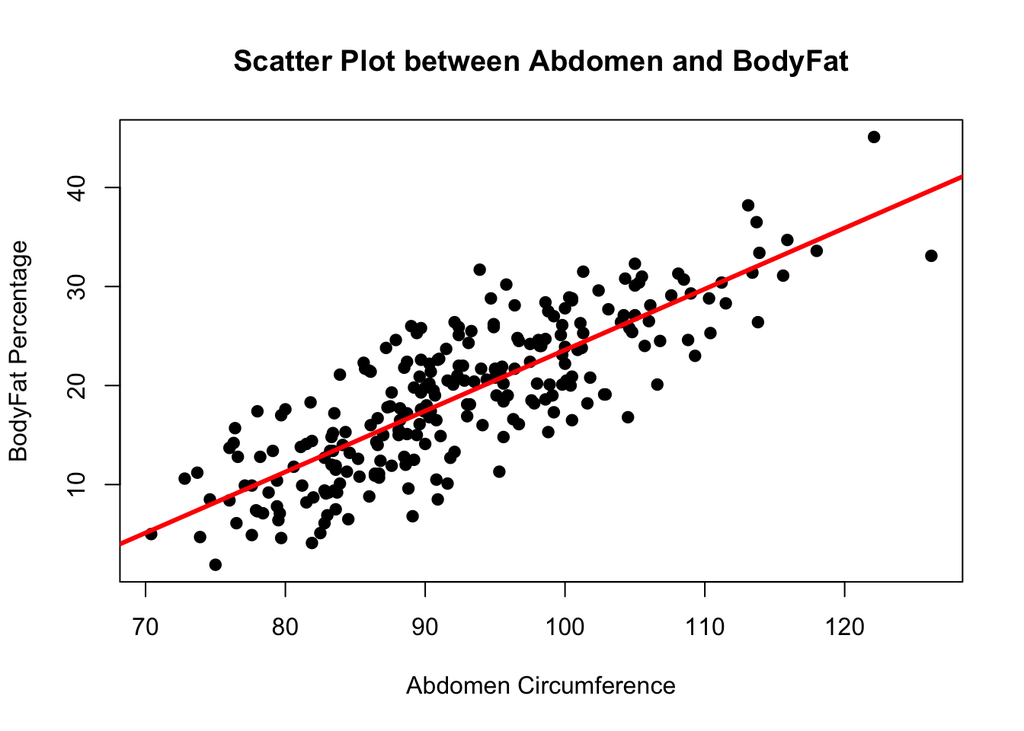

```r
plot(BodyFat$ABDOMEN, BodyFat$BODYFAT, main = "Scatter Plot between Abdomen and BodyFat", xlab = "Abdomen Circumference",
     ylab = "BodyFat Percentage", pch = 19)
abline(lm.abdomen, col = "red", lwd = 3)
```

Then we perform a t-test to check if SLR model is significant.
$$H_0: \beta_1 = 0 \\
H_1:\beta_1 ≠ 0 \\$$
The t-statistic is 22.52 and p-value is less than 2e-16. With any significant level, we can reject the null in favor of the alternative hypothesis. In plain English, we conclude that there is a linear relationship between Abdomen circumference and Body Fat Percentage.

We can also get a 95% confidence interval. We are 95% confident that the true Intercept for our model is between (-42.996683, -32.9861436) and the true slope coefficient is between (0.562028, 0.6697498).

```r
confint(lm.abdomen)
```

```
##                  2.5 %      97.5 %
## (Intercept) -42.996683 -32.9861436
## ABDOMEN       0.562028   0.6697498
```

To use our model, for example, we have a person whose abdomen circumference is about 120 centimeters. We can plug-in 120 into this formula to get his Body Fat Percentage is around 35.91526%

We can also derive a prediction interval for this person. There is a 95% probability that this man’s body fat percentage is between (27.18333, 44.64718)

```r
predict(lm.abdomen, newdata = data.frame(ABDOMEN = 120), interval = "predict")
```

```
##        fit      lwr      upr
## 1 35.91526 27.18333 44.64718
```

## Step 4: Diagnostics

After model fitting, we diagnose the SLR assumptions with a residual plot and a QQ plot.

Residual plot: good for diagnosing (i) linearity vioations, (ii) homoskedasticity violations, and (iii) detecting outliers in Y

QQ plot: good for diagnosing violations to Normality

First, we use a residual plot to check linearity and homoskedasticity.

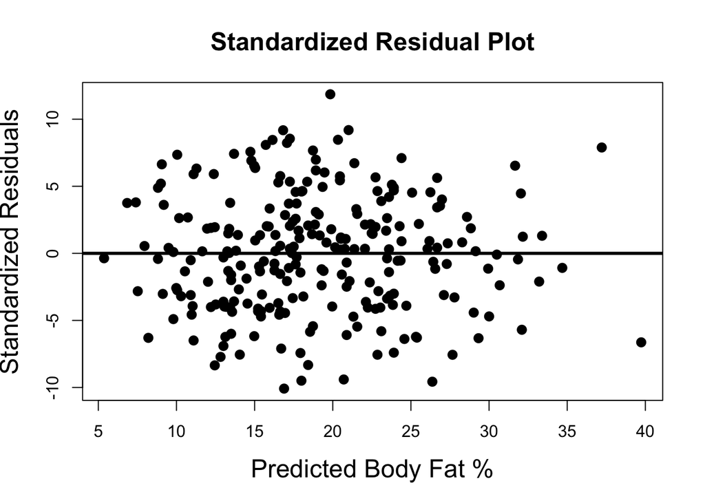

```r
par(mfrow = c(1,1))
plot(predict(lm.abdomen),resid(lm.abdomen),pch=19,cex=1.2,cex.lab=1.5,cex.main=1.5,
    xlab="Predicted Body Fat %", ylab="Standardized Residuals",main="Standardized Residual Plot")
abline(a=0,b=0,col="black",lwd=3)
```

Then we use a QQ plot to check the normality.

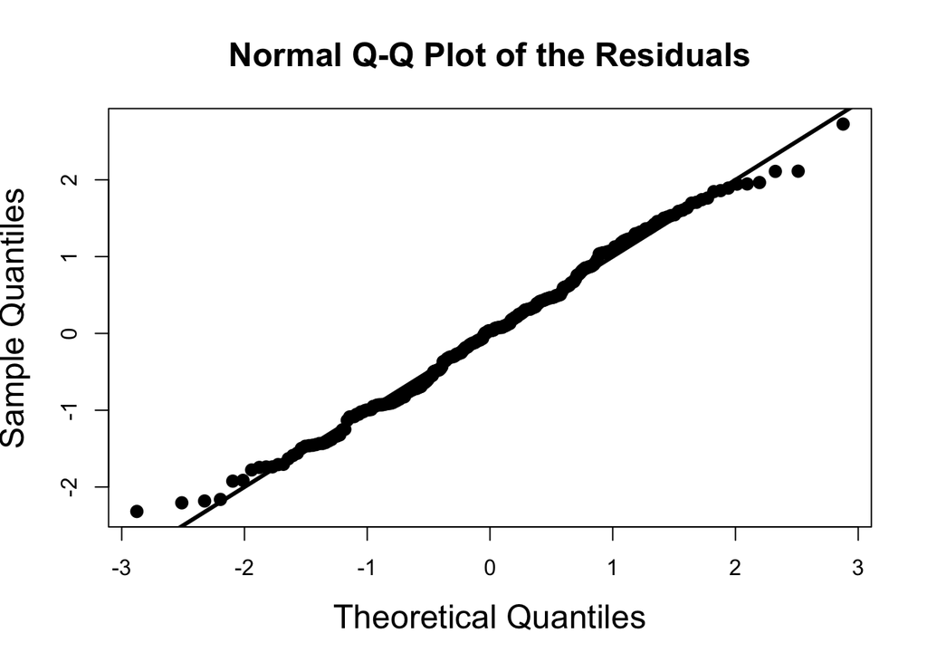

```r
qqnorm(rstandard(lm.abdomen),pch=19,cex=1.2,cex.lab=1.5,cex.main=1.5,
      main="Normal Q-Q Plot of the Residuals")
abline(a=0,b=1,col="black",lwd=3)
```

## Outliers in Y, Leverage and Influential Points

From our model of body fat based on abdomen, there also does not seem to be any outliers in Y (this is subjective though).

To better discern the outliers, we also check for leverage and influential points.

For leverage points, we’ll use pii measures from the lectures. For influential points, we will use both the Cook’s distance and the pii measures.

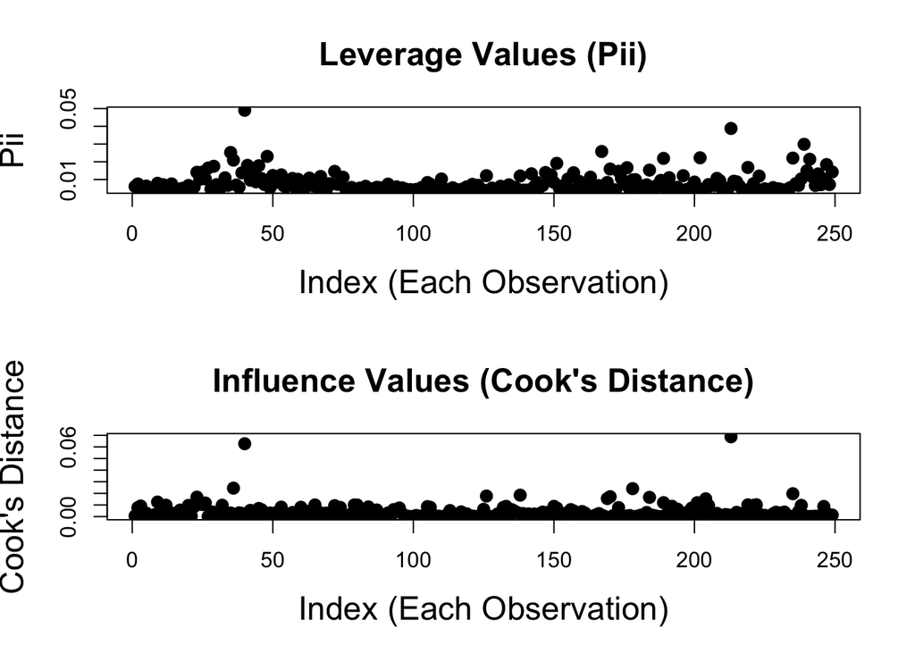

```r
pii = hatvalues(lm.abdomen)
cooki = cooks.distance(lm.abdomen)

par(mfrow = c(2,1))
n = dim(BodyFat)[1]
plot(1:n,pii,type="p",pch=19,cex=1.2,cex.lab=1.5,cex.main=1.5,
     xlab="Index (Each Observation)",ylab="Pii",main="Leverage Values (Pii)")
plot(1:n,cooki,type="p",pch=19,cex=1.2,cex.lab=1.5,cex.main=1.5,
     xlab="Index (Each Observation)",ylab="Cook's Distance",main="Influence Values (Cook's Distance)")
```

There are two leverage points (the 40th and 213th observation). And both of them seems to be influential points by comparing both the Cook’s distance and the leverage values.

We remove the two influential points are made a new SLR model.

```r
BodyFat = BodyFat[-c(40, 213), ]
lm.abdomen = lm(BODYFAT ~ ABDOMEN, data = BodyFat)
summary(lm.abdomen)
```

```
##
## Call:
## lm(formula = BODYFAT ~ ABDOMEN, data = BodyFat)
##
## Residuals:
##      Min       1Q   Median       3Q      Max
## -10.0806  -3.3041   0.1507   2.8809  11.8653
##
## Coefficients:
##              Estimate Std. Error t value Pr(>|t|)
## (Intercept) -37.95511    2.62213  -14.47   <2e-16 ***
## ABDOMEN       0.61544    0.02831   21.74   <2e-16 ***
## ---
## Signif. codes:  0 '***' 0.001 '**' 0.01 '*' 0.05 '.' 0.1 ' ' 1
##
## Residual standard error: 4.328 on 245 degrees of freedom
## Multiple R-squared:  0.6586, Adjusted R-squared:  0.6572
## F-statistic: 472.7 on 1 and 245 DF,  p-value: < 2.2e-16
```

This the SLR model we improved.
$$BodyFatPercentage = 0.61544*ABDOMEN - 37.95511$$

```r
summary(lm.abdomen)
```

```
##
## Call:
## lm(formula = BODYFAT ~ ABDOMEN, data = BodyFat)
##
## Residuals:
##      Min       1Q   Median       3Q      Max
## -10.0806  -3.3041   0.1507   2.8809  11.8653
##
## Coefficients:
##              Estimate Std. Error t value Pr(>|t|)
## (Intercept) -37.95511    2.62213  -14.47   <2e-16 ***
## ABDOMEN       0.61544    0.02831   21.74   <2e-16 ***
## ---
## Signif. codes:  0 '***' 0.001 '**' 0.01 '*' 0.05 '.' 0.1 ' ' 1
##
## Residual standard error: 4.328 on 245 degrees of freedom
## Multiple R-squared:  0.6586, Adjusted R-squared:  0.6572
## F-statistic: 472.7 on 1 and 245 DF,  p-value: < 2.2e-16
```

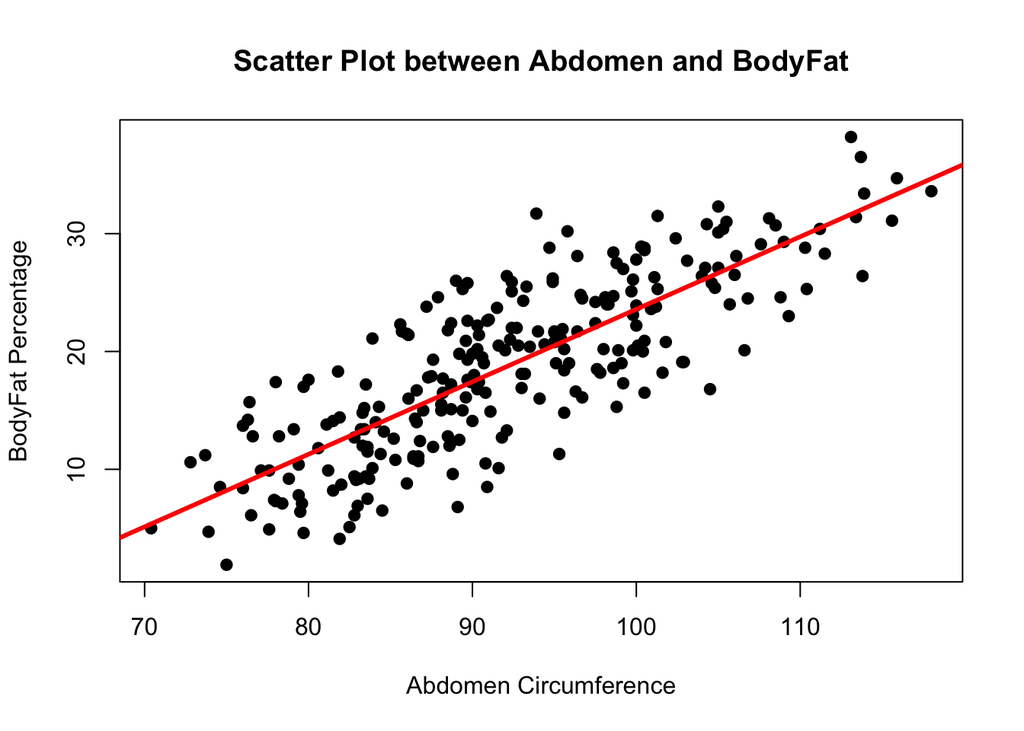

```r
plot(BodyFat$ABDOMEN, BodyFat$BODYFAT, main = "Scatter Plot between Abdomen and BodyFat", xlab = "Abdomen Circumference",
     ylab = "BodyFat Percentage", pch = 19)
abline(lm.abdomen, col = "red", lwd = 3)
```

Then we perform a t-test to check if SLR model is significant.
$$H_0: \beta_1 = 0 \\
H_1:\beta_1 ≠ 0 \\$$
The t-statistic is 21.74 and p-value is less than 2e-16. With any significant level, we can reject the null in favor of the alternative hypothesis. In plain English, we conclude that there is a linear relationship between Abdomen circumference and Body Fat Percentage.

We can also get a 95% confidence interval. We are 95% confident that the true Intercept for our model is between (-43.1199043, -32.7903198) and the true slope coefficient is between (0.5596846, 0.6711946).

```r
confint(lm.abdomen)
```

```
##                   2.5 %      97.5 %
## (Intercept) -43.1199043 -32.7903198
## ABDOMEN       0.5596846   0.6711946
```

We can also derive a prediction interval for this person. There is a 95% probability that this man’s body fat percentage is between (27.21593, 44.57935)

```r
predict(lm.abdomen, newdata = data.frame(ABDOMEN = 120), interval = "predict")
```

```
##        fit      lwr      upr
## 1 35.89764 27.21593 44.57935
```

## Summary of analysis:

Body Fat Pct = 0.6*Abdomen-38

Possible rule of thumb: multiply abdomen circumference by 0.6 and minus 38. The result of our analysis shows that the percentage of body fat has a positive linear relationship with abdomen circumference. Our model provides a simple, convenient way to estimate the body fat based on abdomen circumference.

Strengths and Weakness of Model: I think the SLR is a reasonable model between body fat % and abdomen circumference, despite some caveats. Linearity: seems reasonable based on the residual plot and scatter plot. Normally distributed errors: seems plausible from the QQ plot diagnostic. However, there may be possibly skinny tail or right skew issues. Our model is straightforward and easy to understand. It can be easily updated with new data. Overall, our model provides a cost-efficient, convenient way to estimate the body fat purely based on abdomen circumference. The linearity, homoscedasticity and normality all seem plausible. However, there may be possibly skinny tail or right skew issues.

Contribution: Chunyu Luo: Step 1 reviewed, Step 4 codes and graphs Sabrina Liu: Step 2 codes and graphs Kechen Lu: Step 2 codes and graphs, Summary of analysis edited Steven Yang: Step 1 codes and graphs, Step 3 codes and graphs